# Work Hours and Job Satisfaction Among UK Data Scientists

Safa A Elrais

21/05/2021

## Introduction :

### *Background*

Today, Data Science is one of the hottest Jobs in Technology with Data Scientists are among the highest paid with an average annual income of 140849£ in the UK. Sometimes the long working hours, the complexity of data problems, the high expectations from employees exert tremendous pressure on Data Scientists. The stressful nature of the job may affect the level of Job Satisfaction leading to many more Data Scientists leaving their jobs.

### *Research Questions*

By this Data Visualization, we aim to investigate :

1. The overall level of Satisfaction of UK Data Scientists.
2. Is the level of Satisfaction affected by How many hours do they work per week.
3. Is there a difference in level of Satisfaction between Men and Woman Who work the same amount of hours per week .

### *Data Origins*

The data is sourced directly from [Stack Overflow Annual Developer Survey](https://insights.stackoverflow.com/survey/) for the year 2020. The Survey consists of 6 sections and 61 variables . Respondents were from all over the world

```r
#load the data

datafile= "C:/Users/44751/OneDrive/Desktop/200266165/PSYC6422/2020.csv"

df0 <- read.csv(datafile)
```

The analysis focuses mainly on 4 variables , the following table provides each variable names and its explanation.

| Variable.name | Explanation |
| --- | --- |
| Gender | Either Man , Woman , Non-Binary |
| Country | Counrty where respondent currently lives |
| JobSat | Level of satisfaction as 5 likert scale of satisfaction |
| WorkWeekHrs | How many hours does the respondent work per week |

## Data cleaning and Preparation :

To be able to create the visualization we are thinking of , our data set need to go through several steps of date filtering , variables selection and data cleaning before it is ready to plot .

The following chunk of code is required :

```r
# loading the required libararies

library(dplyr)                                                 #This loads the dplyr library
library(outliers)

# filtering , selecting and removing missing values from the dataset


df <- df0 %>%

  filter(Country == "United Kingdom", Gender == "Man" | Gender == "Woman") %>%                      # this Subsets Data Frame only retaining United kingdom data
  select("Gender","Country","JobSat","WorkWeekHrs") %>%        # this Subsets Data frame to include specific variables

  na.omit(df)                                                  # this removes the missing values from data frame


# removing outlier values from WorkWeekHrs column using the quantiles method

Q1 <- quantile(df$WorkWeekHrs, .25)                           # this calculates the Q1

Q3 <- quantile(df$WorkWeekHrs, .75)                           # this calculates the Q3

IQR <- IQR(df$WorkWeekHrs)                                    # this calculates the interquantile range


clean_df<- subset(df, df$WorkWeekHrs> (Q1 - 1.5*IQR) & df$WorkWeekHrs< (Q3 + 1.5*IQR)) # this subsets data frame and retain only data between (Q1 - 1.5*IQR) and (Q3 + 1.5*IQR)


head(clean_df,5)                                              #this shows the first 5 rows of the processed dataframe
```

```
##   Gender        Country                JobSat WorkWeekHrs
## 1    Man United Kingdom        Very satisfied          36
## 2    Man United Kingdom Slightly dissatisfied          40
## 4    Man United Kingdom Slightly dissatisfied          37
## 5    Man United Kingdom    Slightly satisfied          40
## 6    Man United Kingdom        Very satisfied          40
```

```r
summary(clean_df)                                             #this shows summary statistics
```

```
##     Gender            Country             JobSat           WorkWeekHrs
##  Length:2171        Length:2171        Length:2171        Min.   :33.00
##  Class :character   Class :character   Class :character   1st Qu.:37.00
##  Mode  :character   Mode  :character   Mode  :character   Median :38.00
##                                                           Mean   :38.42
##                                                           3rd Qu.:40.00
##                                                           Max.   :44.00
```

## Data Visualization :

### *Visualization 1 : The level Of Satisfaction Among Data Scientists*

#### *figure 1:*

The below graph displays the overall rating of Satisfaction among UK Data Scientists. We see that the Majority of UK Data Scientists are either very Satisfied or partially Satisfied about their Jobs , while around 20 % reported a Job dissatisfaction and about 10 % were neutral toward their jobs .

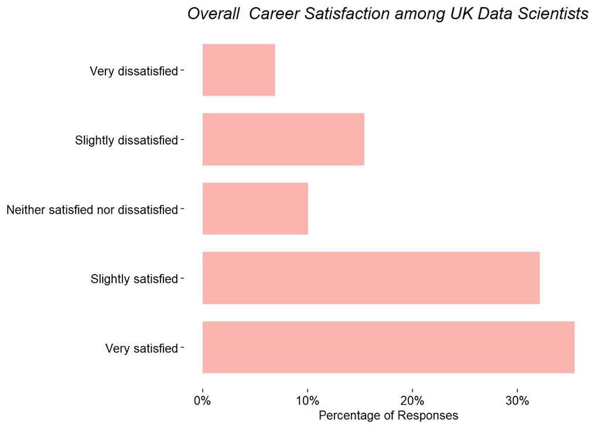

```r
# labeling the parameter of the graph

title <- "Overall  Career Satisfaction among UK Data Scientists "     # this is the title

ylab <- "Percentage of Responses"                                     # this is the y axis label


# creating the bar graph

library(ggplot2)                                                      #this loads the ggplot library


figure1 <- ggplot(data=clean_df, mapping = aes(x=JobSat, fill= "JobSat"))

figure1 + geom_bar(mapping = aes(y=..prop..,group="JobSat"), width = 0.75)+
  labs(y =ylab,
       title = title)+
  scale_x_discrete(limits=c("Very satisfied",
                            "Slightly satisfied",
                            "Neither satisfied nor dissatisfied",
                            "Slightly dissatisfied","Very dissatisfied"))+
  scale_y_continuous(labels = scales::percent)+theme(legend.position = "none",
                                                      panel.background = element_blank(),
                                                      plot.title=element_text(family="Times",
                                                                              face="italic",size=14,
                                                                              hjust=0.8),
                                                      axis.title.y = element_blank(),
                                                      axis.title.x = element_text(family= "Times", size = 10),
                                                      text=element_text(size = 10, family="Times"),
                                                      axis.text.x=element_text(colour="black", size = 10),
                                                      axis.text.y=element_text(colour="black", size=10))+
                                                      coord_flip()+ scale_fill_brewer(palette = "Pastel1")
```

#### *figure 2: Weekly Working Hours vs Level of Satisfaction*

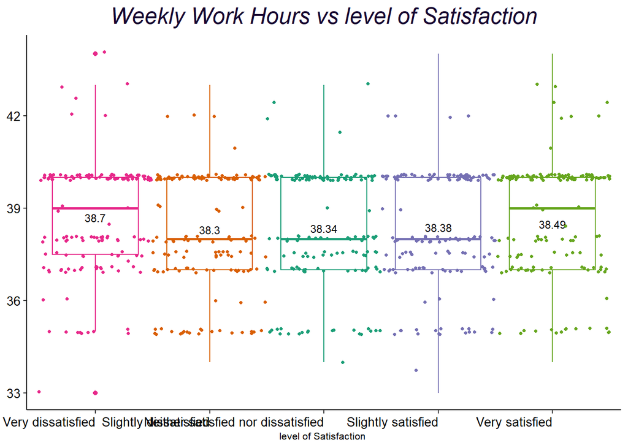

```r
#labeling the parameters of the graph

title = " Weekly Work Hours vs level of Satisfaction "
xlab = "level of Satisfaction "
ylab = "Weekly Work hours "


# calculating the mean values of box plot groups

summary_df <- clean_df %>%
  group_by(JobSat) %>%
  summarise(means=mean(WorkWeekHrs))


figure2 <- ggplot(data=clean_df,mapping = aes(x=JobSat , y=WorkWeekHrs, color = JobSat))

figure2+geom_boxplot()+ geom_text(data=summary_df, aes(y=means, label=round(means,2)),
                                size= 3 ,color='black',position=position_dodge(0.8))+geom_jitter(data = clean_df %>% group_by(JobSat) %>% sample_n(150),position = position_jitter(0.5),size = 0.9)+
                        labs(title = title,
                             x=xlab,
                             y=ylab)+
                        scale_x_discrete(limits=c("Very dissatisfied",
                                "Slightly dissatisfied",
                                "Neither satisfied nor dissatisfied",
                                "Slightly satisfied",
                                "Very satisfied"))+
                        scale_y_continuous(breaks = c(30,33,36,39,42,45))+
                        theme(legend.position = "none",
                              axis.line.x = element_line(size = 0.5, colour="black"),
                              axis.line.y = element_line(size = 0.5, colour = "black"),
                              axis.line = element_line(size=1, colour = "black"),
                              panel.grid.major = element_blank(),
                              panel.grid.minor = element_blank(),
                              panel.border = element_blank(),
                              panel.background = element_blank(),
                              plot.title=element_text(size = 18, family="Times", face
                                                       ="italic",color= "#170630",hjust=0.5),
                              axis.title.y = element_blank(),
                              text=element_text(size = 8, family="Times"),
                              axis.text.x=element_text(colour="black", size = 10,hjust = 1),
                              axis.text.y=element_text(colour="black", size = 10))+
                              scale_color_brewer(palette = "Dark2")
```

#### *figure 3: Difference in level of Job Satisfaction among Men and Women working under 40 hours a week*

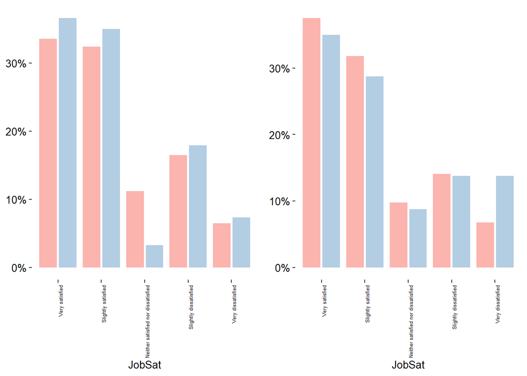

```r
under_40 <- subset(clean_df ,WorkWeekHrs < 40)

figure3 <- ggplot(data = under_40,mapping = aes(x= JobSat , fill = Gender))
figure3 <- figure3+geom_bar(position = "dodge2", mapping = aes(y=..prop.. , group = Gender))+ scale_x_discrete(limits=c("Very satisfied",
                            "Slightly satisfied",
                            "Neither satisfied nor dissatisfied",
                            "Slightly dissatisfied","Very dissatisfied"))+
  scale_y_continuous(labels = scales::percent)+theme(legend.position = "none",
                                                      panel.background = element_blank(),
                                                      plot.title=element_text(family="Times",
                                                                              face="italic",size=14,
                                                                              hjust=0.8),
                                                      axis.title.y = element_blank(),
                                                      axis.title.x = element_text(family= "Times", size = 10),
                                                      text=element_text(size = 10, family="Times"),
                                                      axis.text.x=element_text(colour="black", size = 5, angle = 90 , hjust=1),
                                                      axis.text.y=element_text(colour="black", size=10))+ scale_fill_brewer(palette = "Pastel1")



above_40 <- subset(clean_df , WorkWeekHrs >= 40)
figure4 <- ggplot(data = above_40,mapping = aes(x= JobSat , fill = Gender))
figure4 <- figure4+geom_bar(position = "dodge2", mapping = aes(y=..prop.., group = Gender))+ scale_x_discrete(limits=c("Very satisfied",
                            "Slightly satisfied",
                            "Neither satisfied nor dissatisfied",
                            "Slightly dissatisfied","Very dissatisfied"))+
  scale_y_continuous(labels = scales::percent)+theme(legend.position = "none",
                                                      panel.background = element_blank(),
                                                      plot.title=element_text(family="Times",
                                                                              face="italic",size=14,
                                                                              hjust=0.8),
                                                      axis.title.y = element_blank(),
                                                      axis.title.x = element_text(family= "Times", size = 10),
                                                      text=element_text(size = 10, family="Times"),
                                                      axis.text.x=element_text(colour="black", size = 5, angle = 90, hjust=1),
                                                      axis.text.y=element_text(colour="black", size=10))+scale_fill_brewer(palette = "Pastel1")


# Install gridExtra package

library(grid)
library(gridExtra)
# Load gridExtra package

grid.arrange(figure3, figure4, ncol=2)          # Apply grid.arrange function
```